# DocSummary_Example

2nd Lt. Speranza, 2nd Lt. Gold, 1st Lt. Buck

November 6, 2018

# In Class Example

Now we will walk through a few examples of document summarization (aka automatic summarization).

## LexRankr Example

LexRankr can be used to recreate a text summarizer used on Reddit posts.

## Get Nessasary Packages

These are the nessasary packages needed for the in class example. You can use Pacman in order to install and load in the packages.

```r
pacman::p_load("xml2",
               "rvest",
               "lexRankr")
```

## Load Data Sets

```r
#url to scrape
monsanto_url = "https://www.theguardian.com/environment/2017/sep/28/monsanto-banned-from-european-parliament"

#read page html
page = xml2::read_html(monsanto_url)
#extract text from page html using selector
page_text = rvest::html_text(rvest::html_nodes(page, ".js-article__body p"))
```

Now that the data has been read in, we can perform the lexRank method to obtain the top sentenses. This is an extractive technique and can be useful in getting summaries directly from the article.

```r
#perform lexrank for top 3 sentences
top_3 = lexRankr::lexRank(page_text,
                          #only 1 article; repeat same docid for all of input vector
                          docId = rep(1, length(page_text)),
                          #return 3 sentences to mimick /u/autotldr's output
                          n = 3,
                          continuous = TRUE)
```

```
## Parsing text into sentences and tokens...DONE
## Calculating pairwise sentence similarities...DONE
## Applying LexRank...DONE
## Formatting Output...DONE
```

```r
#reorder the top 3 sentences to be in order of appearance in article
order_of_appearance = order(as.integer(gsub("_","",top_3$sentenceId)))
#extract sentences in order of appearance
ordered_top_3 = top_3[order_of_appearance, "sentence"]
ordered_top_3
```

```
## [1] "Monsanto lobbyists have been banned from entering the European parliament after the multinational refused to attend a parliamentary hearing into allegations of regulatory interference."
## [2] "Monsanto officials will now be unable to meet MEPs, attend committee meetings or use digital resources on parliament premises in Brussels or Strasbourg."
## [3] "A Monsanto letter to MEPs seen by the Guardian said that the European parliament was not “an appropriate forum” for discussion on the issues involved."
```

This is a very simple way to obtain extractive summaries from various articles and documents.

## TextRank

### Jane Austen

We will start by packages that have been developed to help with TextRank method. This is the same algorithm that google uses to pick out summaries of web documents. [(3)](https://www.hvitfeldt.me/2018/03/tidy-text-summarization-using-textrank/)

First, we will install and prepare all of the nessasary packages.

```r
pacman::p_load("tidyverse",
               "tidytext",
               "textrank",
               "rvest")
```

Now we can pull in the data from the url and pull in with tibble. Our tokenizer is sentences. Then we can tokenize again to get the indivdiual words. Finally, we remove stop words

```r
url <- "http://time.com/5196761/fitbit-ace-kids-fitness-tracker/"
article <- read_html(url) %>%
  html_nodes('div[class="padded"]') %>%
  html_text()

#get sentences
article_sentences <- tibble(text = article) %>%
  unnest_tokens(sentence, text, token = "sentences") %>%
  mutate(sentence_id = row_number()) %>%
  select(sentence_id, sentence)
head(article_sentences)
```

```
## # A tibble: 6 x 2
##   sentence_id sentence
##         <int> <chr>
## 1           1 fitbit is launching a new fitness tracker designed for chil~
## 2           2 the fitbit ace looks a lot like the company’s alta tracker,~
## 3           3 the most important of which is fitbit’s new family account ~
## 4           4 parents must approve who their child can connect with via t~
## 5           5 like many of fitbit’s other products, the fitbit ace can au~
## 6           6 but while fitbit’s default move goal is 30 minutes for adul~
```

```r
#get words
article_words <- article_sentences %>%
  unnest_tokens(word, sentence)

#remove stop words
article_words <- article_words %>%
  anti_join(stop_words, by = "word")
```

Now that we have the proper format for textrank, there are only two inputs required for the software to run. *A data.frame with sentences* A data.frame with words Here is the code and the output for summarizing the article.

```r
article_summary <- textrank_sentences(data = article_sentences,
                                      terminology = article_words)
article_summary
```

```
## Textrank on sentences, showing top 5 most important sentences found:
##   1. fitbit is launching a new fitness tracker designed for children called the fitbit ace, which will go on sale for $99.95 in the second quarter of this year.
##   2. fitbit says the tracker is designed for children eight years old and up.
##   3. the fitbit ace looks a lot like the company’s alta tracker, but with a few child-friendly tweaks.
##   4. like many of fitbit’s other products, the fitbit ace can automatically track steps, monitor active minutes, and remind kids to move when they’ve been still for too long.
##   5. above all else, the ace is an effort to get children up and moving.
```

Lastly, we can look at where these sentences took place in the article.

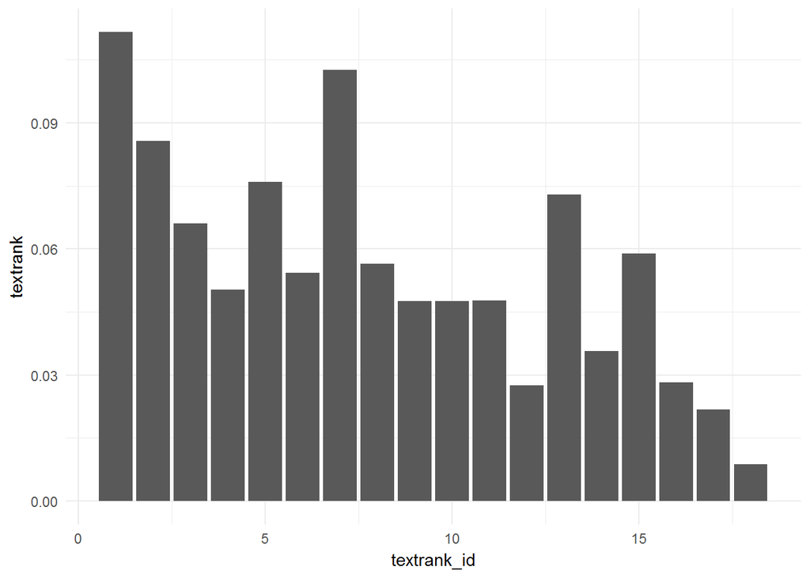

```r
article_summary[["sentences"]] %>%
  ggplot(aes(textrank_id, textrank)) +
  geom_col() +
  theme_minimal()
```

It is interesting to note that the 4 most important sentences in the first half of the article. This logically makes sense because the company writing the article will want to give the reader the information up front.

This example online goes on to see if the same technique would work for a book rather than an article.

Lets get the janeausten book and run the analysis.

```r
pacman::p_load("janeaustenr")

#load in the book and split by chapter
emma_chapters <- janeaustenr::emma %>%
  tibble(text = .) %>%
  mutate(chapter_id = cumsum(str_detect(text, regex("^chapter [\\divxlc]",
                                                 ignore_case = TRUE)))) %>%
  filter(chapter_id > 0) %>%
  group_by(chapter_id) %>%
  summarise(text = paste(text, collapse = ' '))

#remove stop words.
emma_words <- emma_chapters %>%
  unnest_tokens(word, text) %>%
  anti_join(stop_words, by = "word")
```

Now we can use the same code as above to analyze using the text rank software in R and print the graph to see which chapters have the most important information according to the Text Rank algorithm.

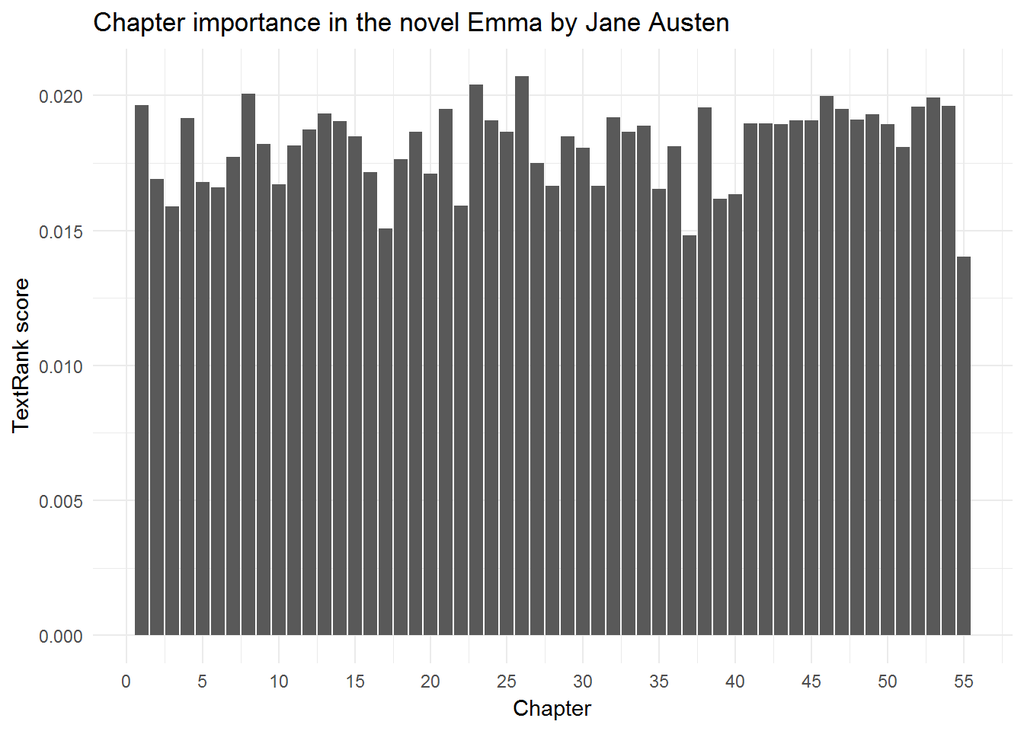

```r
emma_summary <- textrank_sentences(data = emma_chapters,
                                   terminology = emma_words)
#creates the plot
emma_summary[["sentences"]] %>%
  ggplot(aes(textrank_id, textrank)) +
  geom_col() +
  theme_minimal() +
  labs(x = "Chapter",
       y = "TextRank score",
       title = "Chapter importance in the novel Emma by Jane Austen") +
  scale_x_continuous(breaks = seq(from = 0, to = 55, by = 5))
```

There really isn’t that much information you can gather from this. No chapter or chapters seems to have a clear importance over the other ones.

## Using both Methods on Star Wars Movie Script

Both of the examples above were found online. Now we know how each of the packages work, we can try and use these on our own examples.

First we need to download the data set. Obtained through kaggle, we will be using the movie script for Star Wars Episode 4. The data cleaning done on this is very similar to how we cleaned the data for the Harry Potter Books.

```r
#read in the movie scripts'
if (!require("pacman")) install.packages("pacman")
library(pacman)
pacman::p_load(tm,
               pdftools,
               here,
               tau,
               tidyverse,
               stringr,
               tidytext,
               RColorBrewer,
               qdap,
               qdapRegex,
               qdapDictionaries,
               qdapTools,
               data.table,
               coreNLP,
               scales,
               text2vec,
               SnowballC,
               DT,
               quanteda,
               RWeka,
               broom,
               tokenizers,
               grid,
               knitr,
               widyr)
library(readr)

Episode4<-read_file("File/SW_EpisodeIV.txt")
Episode4<-gsub('\\\"'," ",Episode4)

clean <- tibble::tibble(text = Episode4) %>%
    tidytext::unnest_tokens(sentence, text,token ='sentences') %>%
    dplyr::mutate(movie = "Episode4") %>%
    dplyr::select(movie, dplyr::everything())

  Ep4_tidy <-clean



Ep4_tidy
```

```
## # A tibble: 1,770 x 2
##    movie    sentence
##    <chr>    <chr>
##  1 Episode4 character   dialogue   1   threepio   did you hear that?
##  2 Episode4 they've shut down the main reactor.
##  3 Episode4 we'll be destroyed for sure.
##  4 Episode4 this is madness!
##  5 Episode4 2   threepio   we're doomed!
##  6 Episode4 3   threepio   there'll be no escape for the princess this ti~
##  7 Episode4 4   threepio   what's that?
##  8 Episode4 5   threepio   i should have known better than to trust the l~
##  9 Episode4 6   luke   hurry up!
## 10 Episode4 come with me!
## # ... with 1,760 more rows
```

```r
Ep4_tidy$sentence<-gsub(Ep4_tidy$sentence,
      pattern = "[0-9]",
      replacement = ""
      )
head(Ep4_tidy$sentence)
```

```
## [1] "character   dialogue      threepio   did you hear that?"
## [2] "they've shut down the main reactor."
## [3] "we'll be destroyed for sure."
## [4] "this is madness!"
## [5] "   threepio   we're doomed!"
## [6] "   threepio   there'll be no escape for the princess this time."
```

### Lex Rank Method.

```r
Ep4Summary=NULL
for (i in 1:4){


top_3Ep4 = lexRankr::lexRank(Ep4_tidy$sentence[(i-1)*round(nrow(Ep4_tidy)/4)+1:round(nrow(Ep4_tidy)/4)*i],
                          #only 1 article; repeat same docid for all of input vector
                          docId = rep(1, round(length(Ep4_tidy$sentence[1:nrow(Ep4_tidy)])/4)),
                          #return 3 sentences
                          n = 3,
                          continuous = TRUE)

#reorder the top 3 sentences to be in order of appearance in article
order_of_appearance = order(as.integer(gsub("_","",top_3Ep4$sentenceId)))
#extract sentences in order of appearance
ordered_top_3 = top_3Ep4[order_of_appearance, "sentence"]
Ep4Summary<-cbind(Ep4Summary,ordered_top_3)
}
```

```
## Parsing text into sentences and tokens...DONE
## Calculating pairwise sentence similarities...DONE
## Applying LexRank...DONE
## Formatting Output...DONE
## Parsing text into sentences and tokens...DONE
## Calculating pairwise sentence similarities...DONE
## Applying LexRank...DONE
## Formatting Output...DONE
## Parsing text into sentences and tokens...DONE
## Calculating pairwise sentence similarities...DONE
## Applying LexRank...DONE
## Formatting Output...DONE
## Parsing text into sentences and tokens...DONE
## Calculating pairwise sentence similarities...DONE
## Applying LexRank...DONE
## Formatting Output...DONE
```

```r
Ep4Summary
```

```
##      ordered_top_3
## [1,] "vader   commander, tear this ship apart until you've found those plans and bring me the ambassador."
## [2,] "threepio   i see, sir luke."
## [3,] "threepio   master luke here is your rightful owner."
##      ordered_top_3
## [1,] "ben   learn about the force, luke."
## [2,] "tarkin   i think it is time we demonstrate the full power of this station."
## [3,] "leia   governor tarkin, i should have expected to find you holding vader's leash."
##      ordered_top_3
## [1,] "threepio   he says he's found the main control to the power beam that's holding the ship here."
## [2,] "han   hey, luke..."
## [3,] "luke, take red two and three."
##      ordered_top_3
## [1,] "wedge   i'm on him, luke!"
## [2,] "luke   you can't do any more good back there!"
## [3,] "biggs   hurry, luke, they're coming in much faster this time."
```

Again, this is an extractive summarization technique so full sentences are pulled from the data set exactly how it appears in the text. While this might not summarize the movie very well for someone who has never seen star wars, this does a good job of picking out key lines from the movie that would jog someone’s memory of what happened in the movie.

```r
library(textrank)
#get sentences
Ep4_sentences <- tibble(text = Episode4) %>%
  unnest_tokens(sentence, text, token = "sentences") %>%
  mutate(sentence_id = row_number()) %>%
  select(sentence_id, sentence)


Ep4_sentences$sentence<-gsub('[[:digit:]]+',' ',Ep4_sentences$sentence)
head(Ep4_sentences)
```

```
## # A tibble: 6 x 2
##   sentence_id sentence
##         <int> <chr>
## 1           1 character   dialogue       threepio   did you hear that?
## 2           2 they've shut down the main reactor.
## 3           3 we'll be destroyed for sure.
## 4           4 this is madness!
## 5           5 "    threepio   we're doomed!"
## 6           6 "    threepio   there'll be no escape for the princess this~
```

```r
Part1_sen<-Ep4_sentences[1:round(nrow(Ep4_sentences)/4),]
#get words
Part1_words <- Part1_sen %>%
  unnest_tokens(word, sentence)

#remove stop words
Part1_words <- Part1_words %>%
  anti_join(stop_words, by = "word")
head(Part1_words)
```

```
## # A tibble: 6 x 2
##   sentence_id word
##         <int> <chr>
## 1           1 character
## 2           1 dialogue
## 3           1 threepio
## 4           1 hear
## 5           2 shut
## 6           2 main
```

```r
#Part1_summary <- textrank_sentences(data = Part1_sen,
#                                   terminology = Part1_words)
#Part1_summary

#Part1_summary[["sentences"]] %>%
 # ggplot(aes(textrank_id, textrank)) +
  #geom_col() +
  #theme_minimal() +
  #labs(x = "Line",
  #     y = "TextRank score",
   #    title = "Script Line from the first quarter of Star Wars Episode 4") +
#  scale_x_continuous(breaks = seq(from = 0, to = 55, by = 5))
```

Our hope is that now you know enough about these methods and how to format them that everyone will feel comfortable in using these summarization techniques in their own final project.

# References

1. [LexRank Example for Online Article Summarization](https://adamspannbauer.github.io/2017/12/17/summarizing-web-articles-with-r/)
2. [TextRank By Thomas W. Jones](https://cran.r-project.org/web/packages/textmineR/vignettes/e_doc_summarization.html)
3. [TextRank example for Books](https://www.hvitfeldt.me/2018/03/tidy-text-summarization-using-textrank/)